# JBalson_CaseStudy1

# 4. Compute the median alcohol content and international bitterness unit for each state. Plot a bar chart to compare.

[figure not shown]

```r
#First create two dataframes for each (ABV and IBU)
AggAbv<-aggregate(abv~state, data=BeersBrew, median) #median alcohol content by state
#arrange(AggAbv,desc(abv)) #sort median alcohol content by state in descending order
AggIbu<-aggregate(ibu~state, data=BeersBrew, median)
#arrange(AggIbu,desc(ibu)) #sort median international bitterness unit in descending order

AbvIbu<-merge(AggAbv,AggIbu,by="state")
#AbvIbu
#str(AbvIbu)
#summary(AbvIbu)

library(ggplot2)

state<-factor(AbvIbu$state)
abv<-c(AbvIbu$abv)
ibu<-c(AbvIbu$ibu)
values<-c(ibu,abv*1000)
Key<-c(rep("ABV",50),rep("IBU",50))
mydata<-data.frame(state,values)

pAbv<-ggplot(mydata, aes(x=reorder(state,-values),values))+geom_bar(stat="identity", aes(fill=Key), position="dodge")
pAbv+labs(y="Median (ABVx1,000)")+labs(x="State")+labs(title="Median ABV and IBU by State (ABV desc)")
```

[figure not shown]

```r
values<-c(abv*1000,ibu)
pIbu<-ggplot(mydata, aes(x=reorder(state,-values),values))+geom_bar(stat="identity", aes(fill=Key), position="dodge")
pIbu+labs(y="Median (ABVx1,000)")+labs(x="State")+labs(title="Median ABV and IBU by State (IBU desc)")
```

# 5. Which state has the maximum alcoholic beer? Which state has the most bitter beer?

```r
#First we'll find the state(s) with the highest alcohol content (ABV):
StateMaxAbu<-arrange(AbvIbu,desc(abv)) #arrange all states in descending order by abv
head(StateMaxAbu,5) #Looks at top 5
```

```
##   state    abv  ibu
## 1    DC 0.0625 47.5
## 2    KY 0.0625 31.5
## 3    MI 0.0620 35.0
## 4    NM 0.0620 51.0
## 5    WV 0.0620 57.5
```

```r
#Kentucky and The Distric of Columbia are tied for brewing beers with the highest alcohol content, at 6.25%


#Next we'll find the state(s) with the bitterest beer (IBU):
StateMaxIbu<-arrange(AbvIbu,desc(ibu)) #arrange all states in descending order by IBU
head(StateMaxIbu,5) #Looks at top 5
```

```
##   state   abv  ibu
## 1    ME 0.051 61.0
## 2    WV 0.062 57.5
## 3    FL 0.057 55.0
## 4    GA 0.055 55.0
## 5    DE 0.055 52.0
```

```r
#Maine has the bitterest beer at 61 IBU
```

# 6. Summary statistics for ABV (Alcohol by volume) variable.

```r
#Summary stats below suggest some left skew and small variance, i.e. - the craft brews tend to be centered
#around a higher ABV
mean(abv)
```

```
## [1] 0.05577
```

```r
quantile(abv) #0% = min, 25% = Q1, 50% = median (equivalent to Q2), 75% = Q3, and 100% = max
```

```
##     0%    25%    50%    75%   100%
## 0.0400 0.0550 0.0560 0.0580 0.0625
```

```r
sd(abv) #standard deviation of the sampled ABV
```

```
## [1] 0.00422361
```

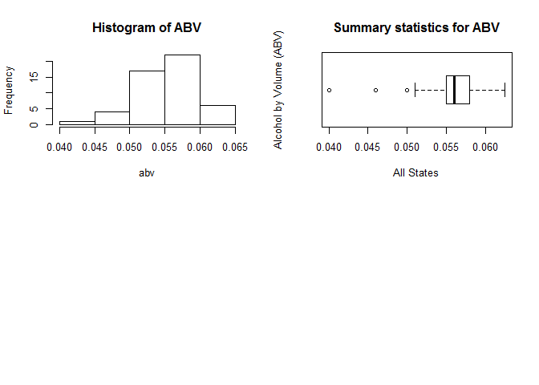

```r
#Below we provide two visual representations of the summary statistics
#The histogram or the boxplot can be used here, or both.  Pick your poison.
par(mfrow = c(2,2))  #2x2 matrix of plots
hist(abv, main="Histogram of ABV")
boxplot(abv, data=AbvIbu, ylab="Alcohol by Volume (ABV)", xlab="All States", main="Summary statistics for ABV", horizontal = TRUE)
```

## 7. Is there a relationship between the bitterness of the beer and its alcoholic content?

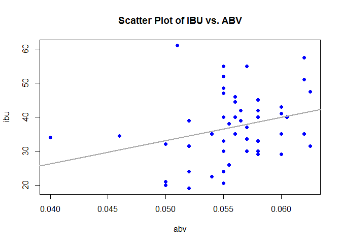

```r
#Fist we'll plot ABV vs. IBU and add a trend line to get a visual representation
plot(abv,ibu,pch=19,col="blue", main="Scatter Plot of IBU vs. ABV")
#pch changes point shape, col changes the color
abline(lm(ibu~abv),col="darkgray",lwd=2) #adds a trend line to the plot, lwd changes line thickness
```

```r
#Next, we'll run a Pearson's correlation and give a full analysis

#We wish to know whether there is a correlation between bitterness of the beer and its alcohol content.
#Ho: There is no correlation
#Ha: There is a correlation

cor.test(abv,ibu)  #for test for whether correlation is 0 (H0) or not 0 (Ha) and CI.
```

```
##
##  Pearson's product-moment correlation
##
## data:  abv and ibu
## t = 2.0371, df = 48, p-value = 0.04717
## alternative hypothesis: true correlation is not equal to 0
## 95 percent confidence interval:
##  0.004066385 0.519640151
## sample estimates:
##       cor
## 0.2820948
```

```r
#From the correlation test above we get a t-value of 2.04 and p-value of 0.047 using a 95% confidence interval
#Therefore, we reject the null hypothesis that there is no correlation
#Conclusion:  Although we rejected the null hypothesis, the results are not overwhelmingly convincing.
#The sample correlation is only 0.28, and it is likely that breweries make stronger beer more bitter because
#that is the taste that the breweries believe consumers are looking for in stronger beers.
#Because this is an observational study, the results only apply to the samples selected in the dataset and no
#causal relationship can be made to infer that stronger beers are inherently more bitter.  Rather, this only
#shows that (from the beers chosen in this dataset) beers with higher alcoholcontent tend to be more bitter.
```

# Project Conclusion: